# R Text Mining with Quanteda & Tidytext

Abby Youran QIN

### Installing & Importing Libraries

```r
packages <- c("tidyverse", # For data frame processing
              "quanteda", # For text processing
              "quanteda.textmodels",
              "quanteda.textstats",
              "quanteda.textplots",
              "knitr", # For html knitting
              "tidytext", # For sentiment analysis
              "ggplot2", # For visualization
              "ggrepel", # For visualizing texts with minimal overlap
              "fastDummies") # For creating dummy variables

installed_packages <- packages %in% rownames(installed.packages())
if (any(installed_packages == FALSE)) {
  install.packages(packages[!installed_packages], repos = 'http://cran.us.r-project.org')
}
invisible(lapply(packages, library, character.only = TRUE))
```

### Importing & Cleaning Files

```r
setwd("/Users/abby/Documents/GitHub/ProgrammingProgramForProletariat/HelloWorld/R_2_TextMining")
df <- read.csv("blkchain&env.csv")
summary(df)
```

```
##        X             Length           Date              Source
##  Min.   :  1.0   Min.   : 105.0   Length:470         Length:470
##  1st Qu.:118.2   1st Qu.: 353.0   Class :character   Class :character
##  Median :235.5   Median : 489.0   Mode  :character   Mode  :character
##  Mean   :235.5   Mean   : 693.2
##  3rd Qu.:352.8   3rd Qu.: 756.0
##  Max.   :470.0   Max.   :9807.0
##      Body
##  Length:470
##  Class :character
##  Mode  :character
##
##
##
```

```r
df$Date <- as.Date(df$Date)
df$Source <- as.factor(df$Source)
df$year_month <- format(as.Date(df$Date), "%Y-%m")
# extract year and month information and add one more column called "year_month"

summary(df)
```

```
##        X             Length            Date                         Source
##  Min.   :  1.0   Min.   : 105.0   Min.   :2019-03-23   Blockchain.News :218
##  1st Qu.:118.2   1st Qu.: 353.0   1st Qu.:2021-07-20   CryptoDaily     : 66
##  Median :235.5   Median : 489.0   Median :2022-06-29   Brave New Coin  : 54
##  Mean   :235.5   Mean   : 693.2   Mean   :2022-01-26   Bitcoin Magazine: 42
##  3rd Qu.:352.8   3rd Qu.: 756.0   3rd Qu.:2022-08-25   Cryptonews.com  : 36
##  Max.   :470.0   Max.   :9807.0   Max.   :2022-10-12   AMBCrypto       : 25
##                                                        (Other)         : 29
##      Body            year_month
##  Length:470         Length:470
##  Class :character   Class :character
##  Mode  :character   Mode  :character
##
##
##
##
```

## Text Processing with Quanteda

- References:
  - [Quanteda Tutorials](https://tutorials.quanteda.io/)
  - [NTNU ENC2036 Corpus Linguistics](https://alvinntnu.github.io/NTNU_ENC2036_LECTURES/corpus-analysis-a-start.html#keyword-in-context-kwic)
- Structure of quanteda objects:
  - **Corpus**: The library of original texts, retaining the structure of articles, and containing document-level variables (docvars). The best practice is to *keep the corpus as it originally is*, without recording any changes that occur during the text processing onto the corpus.
  - **Tokens**: Texts are tokenized, and stored as vectors with *positions of words preserved*. During the tokenization process, we can remove stopwords, punctuations, numbers, urls, symbols, etc. These changes should be recorded onto the dfm object but not the corpus object.
  - **Document-feature matrix (dfm)**: A large matrix with documents as rows, features (unique words) as columns, and different features’ numbers of occurrences in different documents as cells. In a dfm, *positions of words are not preserved*.

### Corpus

**Step 1**. Creating a corpus using corpus() function.

```r
corp <- corpus(df$Body, # the first parameter is the column that contain your texts
               # the docvars argument takes in variables associated with your texts (aka. metadata)
               docvars = data.frame(Date=df$Date,
                                    Source=df$Source,
                                    Length=df$Length,
                                    year_month=df$year_month))
summary(corp, 5) # Check the first five rows of your corpus, by default r will output 100 rows
```

|  | Text | Types | Tokens | Sentences | Date | Source | Length | year_month |
| --- | --- | --- | --- | --- | --- | --- | --- | --- |
| 1 | text1 | 241 | 487 | 23 | 2022-10-12 | Cryptonews.com | 477 | 2022-10 |
| 2 | text2 | 1768 | 10658 | 560 | 2022-10-11 | Cryptonews.com | 9807 | 2022-10 |
| 3 | text3 | 360 | 888 | 35 | 2022-10-11 | CryptoDaily | 781 | 2022-10 |
| 4 | text4 | 259 | 535 | 26 | 2022-10-11 | CryptoDaily | 476 | 2022-10 |
| 5 | text5 | 311 | 721 | 32 | 2022-10-10 | Decrypt | 662 | 2022-10 |

**Step 2**. Making a plot describing the general temporal trend of the articles.

*2.1*. Getting a summary of all texts in the corpus (e.g., number of tokens and sentences in each article).

```r
corp_sum <- summary (corp, n = Inf)
# We specify n=Inf so that all texts in the corpus are summarized.
# By default, R only summarizes the first 100 texts.
```

*2.2*. Plotting the temporal order on a line graph.

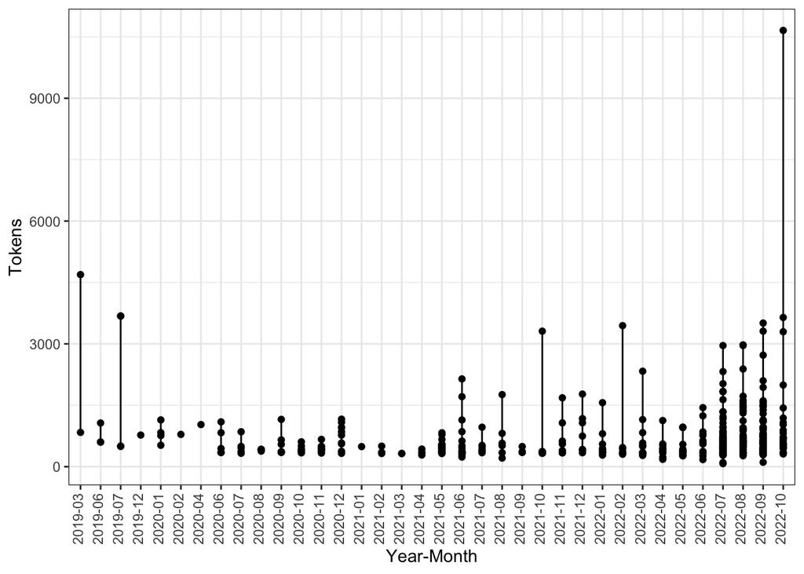

```r
ggplot(corp_sum, aes(x = year_month, y = Tokens)) +
    # year_month on the x-axis, number of tokens on the y-axis
    geom_line() +
    # generating line plot
    geom_point() +
    # marking articles with points
    theme_bw() +
    # using a black & white theme (optional)
    theme(axis.text.x = element_text(angle = 90, vjust = 0.25)) +
    # tilting the x-axis marks in 90 degrees and adjust the marks' positions
    xlab("Year-Month") # changing the x-axis label
```

From this graph, we can see more articles on blockchain and environment were published in 2022 than 2021. But we do not know who published these articles. Why don’t we label the sources on the graph?

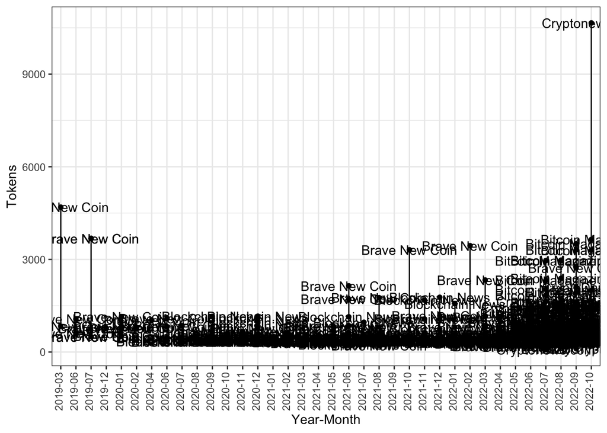

```r
ggplot(corp_sum, aes(x = year_month, y = Tokens)) +
    # year_month on the x-axis, number of tokens on the y-axis
    geom_line() +
    # generating line plot
    geom_point() +
    # marking articles with points
    theme_bw() +
    # using a black & white theme (optional)
    xlab("Year-Month") +
    # changing the x-axis label
    theme(axis.text.x = element_text(angle = 90, vjust = 0.25)) +
    # tilting the x-axis marks in 90 degrees and adjust the marks' positions
    geom_text(aes(label = Source)) # adding sources as labels for articles
```

Well… That’s kinda ugly… To avoid so many overlaps between labels, we can use the geom_text_repel() function to add text labels.

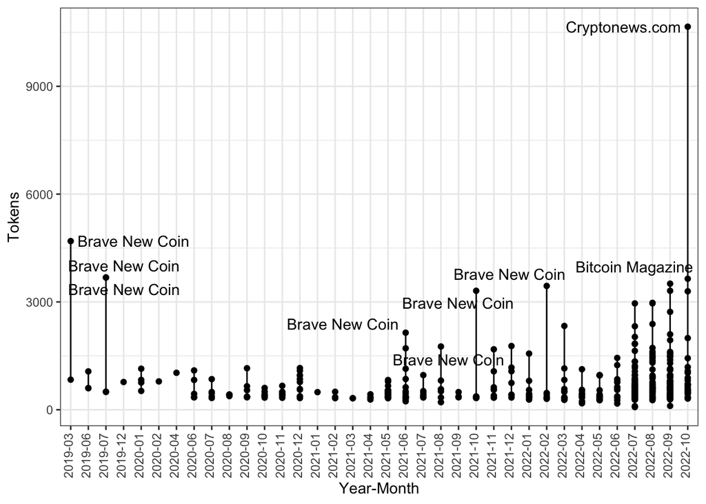

```r
ggplot(corp_sum, aes(x = year_month, y = Tokens)) +
    # year_month on the x-axis, number of tokens on the y-axis
    geom_line() +
    # generating line plot
    geom_point() +
    # marking articles with points
    theme_bw() +
    # using a black & white theme (optional)
    xlab("Year-Month") +
    # changing the x-axis label
    theme(axis.text.x = element_text(angle = 90, vjust = 0.25)) +
    # tilting the x-axis marks in 90 degrees and adjust the marks' positions
    geom_text_repel(aes(label = Source)) # using geom_text_repel to avoid label overlaps
```

This looks much better, but as so many articles are not labeled, we are not sure about the representativeness of the selective labels we see in the graph. To amend it, let’s simply make a stacked bar chart…

*2.3*. Making a stacked bar chart.

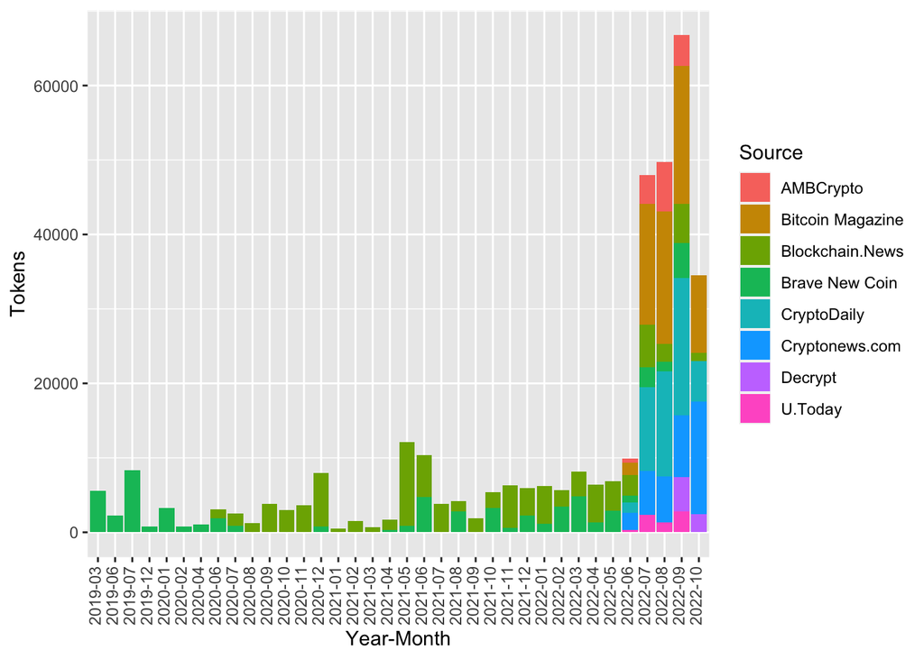

```r
ggplot(corp_sum, aes(x = year_month, y = Tokens)) +
  # year_month on the x-axis, number of tokens on the y-axis
  geom_col(aes(fill=Source)) +
  # creating bars for the graph, coloring bars with articles' sources
  theme(axis.text.x = element_text(angle = 90, hjust = 1, vjust = 0.25)) +
  # tilting the x-axis marks in 90 degrees and adjust the marks' positions
  xlab("Year-Month") # changing the x-axis label
```

Now the graph looks much better! Note that stacked bar charts are not always the optimal solution. That’s the reason why I am showing my trials and errors instead of directly presenting a stacked bar chart as the single correct answer. Feel free to explore different ways to present your data!

**Step 2**. Subsetting the corpus if you need to.

```r
corp_2022 <- corpus_subset(corp, Date >= "2022-01-01")
# Only keeping documents after 2022.01.01
ndoc(corp_2022) # Check number of documents in the subset corpus
```

```
## [1] 311
```

```r
corp_by_media <- corpus_subset(corp, Source %in% c("Blockchain.News", "CryptoDaily", "Brave New Coin"))
# Only keeping documents from these three outlets
ndoc(corp_by_media)
```

```
## [1] 338
```

### Tokens

**Step 1**. Creating a tokens object using tokens() function.

```r
toks <- tokens(corp)
print(toks, 5) # Printing the first five tokenized documents
```

```
## Tokens consisting of 470 documents and 4 docvars.
## text1 :
##  [1] "Hedera"         "("              "HBAR"           ")"
##  [5] "is"             "a"              "leading"        "cryptocurrency"
##  [9] "project"        "focused"        "on"             "creating"
## [ ... and 475 more ]
##
## text2 :
##  [1] "In"             "an"             "exclusive"      "interview"
##  [5] "with"           "cryptonews.com" ","              "Grace"
##  [9] "\""             "Ori"            "\""             "Kwan"
## [ ... and 10,646 more ]
##
## text3 :
##  [1] "Moshnake" "("        "MSH"      ")"        ","        "Ethereum"
##  [7] "("        "ETH"      ")"        ","        "and"      "Ellipsis"
## [ ... and 876 more ]
##
## text4 :
##  [1] "Due"            "to"             "the"            "recent"
##  [5] "collapse"       "of"             "the"            "cryptocurrency"
##  [9] "market"         ","              "Solana"         "("
## [ ... and 523 more ]
##
## text5 :
##  [1] "Vance"       "Spencer"     "discusses"   "crypto"      "regulations"
##  [6] ","           "DeFi"        "investing"   ","           "and"
## [11] "the"         "stigma"
## [ ... and 709 more ]
##
## [ reached max_ndoc ... 465 more documents ]
```

**Step 2**. Checking keywords and phrases in contexts using the kwic() function.

*2.1*. Constructing data frames of key words/phrases and their contexts.

```r
# The kwic() function allows us to go through the tokens object,
# look for the keywords we specify in a vector,
# and tell us the 10 words before and after the keywords
keywords <- kwic(toks, pattern = c("environment*", "sustain*"), window = 10)
# We use "environment*" to match all words starting with the "environment" prefix

# The output is essentially a table, we use kable() function to visualize the table
kable(head(keywords, 10))
```

| docname | from | to | pre | keyword | post | pattern |
| --- | --- | --- | --- | --- | --- | --- |
| text1 | 205 | 205 | region . However , there was not enough momentum to | sustain | this breakout , leading the price of HBAR to retrace | sustain* |
| text1 | 358 | 358 | make for an excellent investment . With the focus on | environmental | , social , and governance ( ESG ) investing increasing | environment* |
| text1 | 402 | 402 | While HBAR is often heralded as one of the most | environmentally-friendly | cryptocurrencies on the market , it pales in comparison to | environment* |
| text2 | 4998 | 4998 | , who is another the OCF contributor who has a | sustainability | background was saying , like , hey , it’s really | sustain* |
| text3 | 464 | 464 | eliminating mining . This transition aims to improve security , | sustainability | , and scalability while lessening the transaction fees on the | sustain* |
| text3 | 763 | 763 | ) aims to offer efficient and well-priced swaps , an | environmentally | friendly yield to token holders , and a solution to | environment* |
| text4 | 156 | 156 | deal of praise for its quickness , efficacy , and | sustainability | . The hybrid technology that underlies Solana ( SOL ) | sustain* |
| text5 | 415 | 415 | That label carries years of baggage , including a negative | environmental | impact . ” I think [ not referencing blockchain or | environment* |
| text6 | 121 | 121 | fact that Bitcoin’s growing energy consumption has drawn criticism from | environmentalists | . Bitcoin miners must overcome the primordial sentiments that are | environment* |
| text6 | 217 | 217 | that the in 2015 would spur Bitcoin toward the more | sustainable | path of renewable energy . However , one shouldn’t be | sustain* |

```r
# If you want to look at phrases...
keyphrases <- kwic(toks, pattern = phrase("crypto min*"), window = 10)
kable(head(keyphrases, 10))
```

| docname | from | to | pre | keyword | post | pattern |
| --- | --- | --- | --- | --- | --- | --- |
| text3 | 429 | 430 | . Ether tokens ( ETH ) were formerly created through | crypto mining | . However , the network recently transitioned from its Proof-of-Work | crypto min* |
| text8 | 249 | 250 | propel transparency in the worldwide carbon credits market , whereas | crypto mining | would trigger renewable microgrids through off-peak demand and decentralization . | crypto min* |
| text13 | 605 | 606 | 50 million as operating deposits for hosting services . * | Crypto mining | company Argo Blockchain plans to sell 3,400 mining machines for | crypto min* |
| text15 | 1 | 2 |  | Crypto miner | Greenridge Generation is on a mission to raise up to | crypto min* |
| text17 | 21 | 22 | Bitcoin mining firm Greenidge is eyeing fresh funding . Controversial | crypto miner | Greenidge Generation is looking to raise up to $ 22.8 | crypto min* |
| text17 | 214 | 215 | South Carolina and New York . In addition , the | crypto miner | has also come under intense criticism regarding its environmental practices | crypto min* |
| text37 | 1 | 2 |  | Crypto mining | firm Compute North has filed for Chapter 11 bankruptcy protection | crypto min* |
| text42 | 45 | 46 | propel transparency in the worldwide carbon credits market , whereas | crypto mining | would trigger renewable microgrids through off-peak demand and decentralization . | crypto min* |
| text52 | 69 | 70 | successful completion of the Merge , the proof-of-work approach that | crypto miners | used to compete to add new transactions to Ethereum’s ledger | crypto min* |
| text66 | 510 | 511 | the White House released a highlighting the environmental concerns of | crypto mining | . In response , founder of MicroStrategy and Bitcoin maximalist | crypto min* |

*2.2*. Visualizing key word/phrases occurrences, for which we need to connect the keywords data frame to the corpus summary data frame to retrieve meta information, e.g., the text’s data of publication.

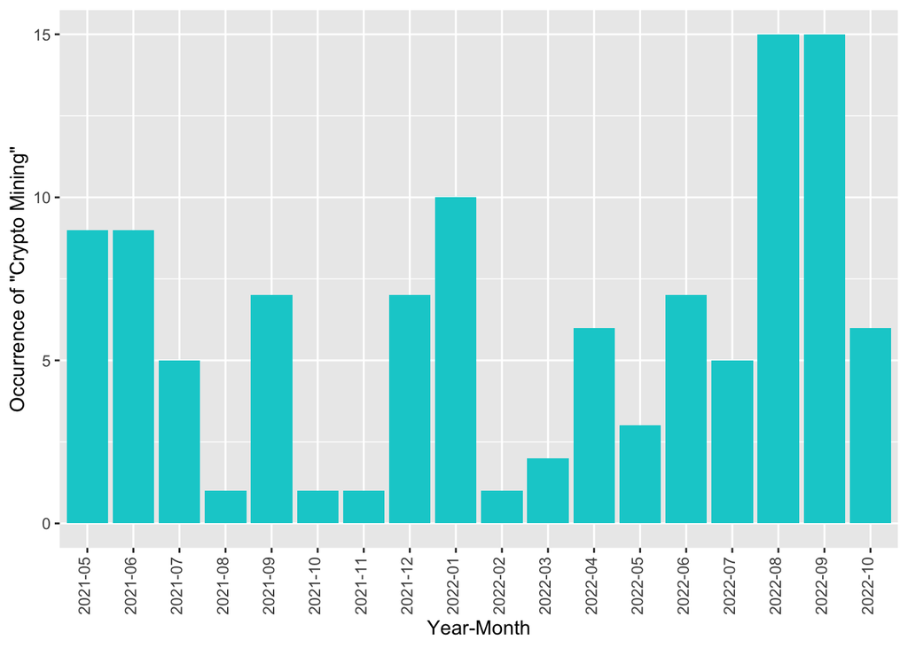

```r
# renaming the text index column of the corpus summary data frame in line with the keyphrases data frame
colnames(corp_sum)[1] <- "docname"

# join the keyphrases data frame and the corpus summary data frame based on the docname column
# for more information on merging data frames, see https://www.datasciencemadesimple.com/join-in-r-merge-in-r/
kp <- keyphrases %>% left_join(corp_sum, by = "docname")

# geom_bar() automatically plot the count/sum of the required variable, so we only need to specify the category we would like to plot (no need to specify x and y axes)
ggplot(kp, aes(year_month)) +
  geom_bar(fill = "darkturquoise") +
  # setting the color of bars
  # for more information about colors, see https://r-graph-gallery.com/ggplot2-color.html
  xlab("Year-Month") +
  ylab("Occurrence of \"Crypto Mining\"") + # using \ escape sign to add quotation marks in character strings
  theme(axis.text.x = element_text(angle = 90, hjust = 1, vjust = 0.25))
```

*2.3*. Visualizing key word/phrases occurrence rate. Now we know the key phrases’ occurrence in each month, but how frequent is it relative to the total tokens published in that month?

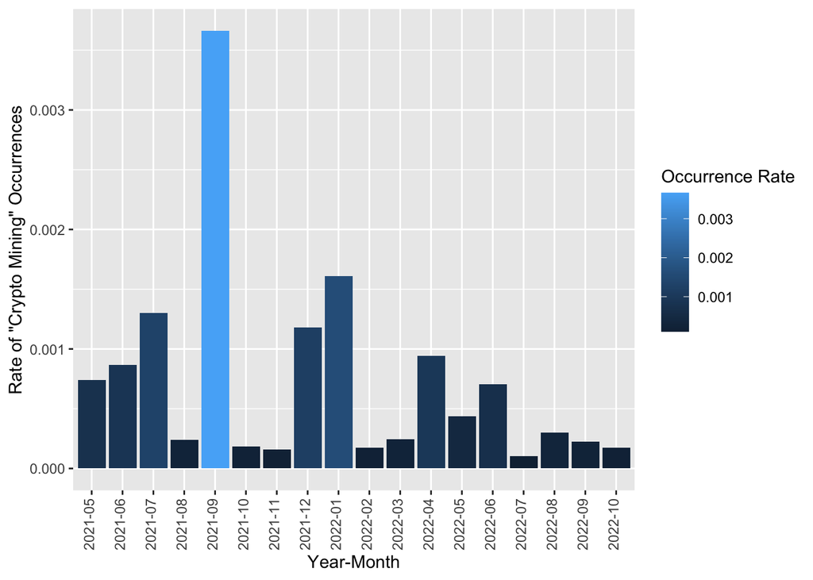

```r
# First, we need to create a new data frame of the number of keyphrase occurrences in each month
month_sum <- kp %>% # taking the newly created kp data frame
  group_by(year_month) %>% # grouping entries by the year_month variable
  summarize(occurrence = n())
  # for each group, count how many entries are there,
  # and record the count into the occurrence column

# Second, we need to calculate the total number of tokens published each month
month_total <- corp_sum %>% # taking the old corpus summary data frame
  group_by(year_month) %>% # grouping entries by the year_month variable
  summarize(total = sum(Tokens))
  # for each group, sum up the token numbers of all entries,
  # and record the sum into the total column

# Third, we will join the keyphrases occurrences data frame and the total tokens data frame based on the year_month column
month_rate <- month_sum %>% left_join(month_total, by = "year_month")
# and calculate the rate of keyword occurrences relative to the total number of tokens
month_rate$rate <- month_rate$occurrence/month_rate$total

# Finally, we can plot the occurrence rate!
ggplot(month_rate, aes(x = year_month, y = rate)) +
    # year_month on the x-axis, occurrence rate on the y-axis
    geom_col(aes(fill = rate)) +
    # adding bars and having their colors filled based on occurrence rate
    xlab("Year-Month") +
    # changing the x-axis label
    ylab("Rate of \"Crypto Mining\" Occurrences") +
    # changing the y-axis label
    labs(fill = "Occurrence Rate") +
    # changing legend label
    theme(axis.text.x = element_text(angle = 90, vjust = 0.25))
```

**Step 3**. Removing punctuation, numbers, URLs, etc.

```r
toks_nostop <- tokens(corp,
                      remove_punct = TRUE,
                      remove_numbers = TRUE,
                      remove_url = TRUE,
                      remove_symbols = TRUE)  %>%
  tokens_tolower(keep_acronyms = FALSE) %>% # turn everything into lower case
  # if keep_acronyms = TRUE, all-uppercase words will not be lowercased
  tokens_remove(pattern = stopwords("en")) # removing stopwords defined by quanteda
print(toks_nostop, 5)
```

```
## Tokens consisting of 470 documents and 4 docvars.
## text1 :
##  [1] "hedera"           "hbar"             "leading"          "cryptocurrency"
##  [5] "project"          "focused"          "creating"         "energy-efficient"
##  [9] "layer-1"          "blockchain"       "fit"              "enterprise"
## [ ... and 226 more ]
##
## text2 :
##  [1] "exclusive"      "interview"      "cryptonews.com" "grace"
##  [5] "ori"            "kwan"           "co-founder"     "orca"
##  [9] "talks"          "solana-based"   "defi"           "orca"
## [ ... and 4,764 more ]
##
## text3 :
##  [1] "moshnake"         "msh"              "ethereum"         "eth"
##  [5] "ellipsis"         "eps"              "best"             "cryptocurrencies"
##  [9] "potential"        "help"             "holders"          "survive"
## [ ... and 435 more ]
##
## text4 :
##  [1] "due"            "recent"         "collapse"       "cryptocurrency"
##  [5] "market"         "solana"         "sol"            "cardano"
##  [9] "ada"            "may"            "recently"       "seen"
## [ ... and 236 more ]
##
## text5 :
##  [1] "vance"       "spencer"     "discusses"   "crypto"      "regulations"
##  [6] "defi"        "investing"   "stigma"      "blockchain"  "gaming"
## [11] "crypto"      "bear"
## [ ... and 301 more ]
##
## [ reached max_ndoc ... 465 more documents ]
```